This is the final tutorial project for CMSC320 by Jiawei Wang and JiYuan Cao

# **Analyzing Racial Hate Crimes from 2013 to 2019**

by Jiawei Wang and JiYuan Cao

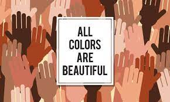

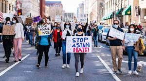

The COVID-19 pandemic might be one of the most influencial pandemic in the modern history. As of May 11 2021, there are more than 158 million confirmed cases and 3.29 million deaths attributed to COVID-19. And it led to the largest global recession since the Great Depression. Numerous lifes had already suffered from this pandemic, but some people vehemently related those tragities with Chinese and Asian who encountered the first outbreak of COVID-19 and suffered because of it. This thought led to an increased amount of racism acts that against Asians and Asian Americans and caused more innocent people to suffer in this difficult time period.

In 2020, the Center for the Study of Hate and Extremism at California State University reported that the Anti-Asian hate crimes had increased by 150%. And the Stop AAPI Hate organization had received 3,795 Asian-hate incidents from March 19, 2020 to February 28, 2021. And here is their report: https://secureservercdn.net/104.238.69.231/a1w.90d.myftpupload.com/wp-content/uploads/2021/03/210312-Stop-AAPI-Hate-National-Report-.pdf .

More Info about 'hate crimes' against Asian Americans: https://www.bbc.com/news/world-us-canada-56218684

As a respond to the ongoing Stop Asian Hate activism, our group members, who are part of the Asian and the anti-racism community, felt the responsibility to act against racism and introduce Asian's current situation to more people in our society. Thus, in our final tutorial project, we would like to introduce the process of data science and analyze historical (racial) hate crimes in the US with slightly more focus on Anti-Asian hate crimes.

The Data Science pipline has the following 5 phases:

1. Data collection
2. Data Manegement/Representation
3. Exploratory data analysis
4. Hypothesis Testing and Machine Learning
5. Communication of insights

And we will go throught those 5 phases in our tutorial project by analyzing racial hate crimes in the U.S. from 2013 to 2019.

**0. Set-up**

Importing modules that we will need for data collection and management.

Pandas will help us deal with tables efficiently, and Numpy will help us to deal with numerical values.

```python
import pandas as pd

import numpy as np
```

## **1. Data collection:**

I believe you already know that data is the most fundamental thing of data science. It's the base of all the fancy data science techniques. Also, we want the data source to be reliable because only real data can reflect reality and provide meaningful insights. So first, let's collect our data.

We collected our data from the FBI Hate Crime database( which is reputable) by downloading their excel packages from year 2013 to 2019. We selected this time range because Anti-Asian incidents were first seperated from other race biased incidents in 2013, and the latest year in FBI's hate crime database is 2019. Here is FBI's website for hate crime data : https://ucr.fbi.gov/hate-crime

Then we transfered downloaded excel files to the google drive for remote accessibility and collaboration.

P.S. Eventhough this time range didn't provide us many information about Anti-Asian hate crimes after COVID-19, we can still analyze historical patterns of race related hate crimes in this time range. And those patterns can provide us a useful background information when we learned about numbers of Anti-Asian hate crimes in 2020 or 2021 from reports or media afterwards.

```python
from google.colab import drive
drive.mount('/content/drive')
```

## **2. Data Management/Representation**

After the data collection, we are still one step away from analyzing it. The Data Management/Representation phase is a big part in the real-life data science since we can't directly use collected data in most cases. Data may contain missing values or irrelavent information, and we don't want those data to interfere our analysis focuses. After selecting useful data, we need to put those data into containers that we can directly use in our future analysis.

The FBI already cleaned the data for us which means there are no missing values in the "real" part of tables to deal with. And it's a good news for us.

But since the FBI Hate Crime excel files are seperated by years (there are 7 files in differnt format) and containing hate crimes other than race-bias incidents, we can't use them directly.

First, we need to extract race related statistics from each table.

And then, we need to aggregate those statistics from 2013 to 2019's files into one table so that we can use it to see the historical pattern in future analysis.

Taking table of 2019 as example, we see that the data we need for race-related bias is from row 6 to row 16, but since years before 2015 only has races from row 6 to row 13, we 'll choose row 6-13 for our data analysis. Those rows contain Anti-white, Anti-Black, Anti-American Indian, Anti-Asian, Anti-Native Hawaiian and Anti-Multiple Races bias motivations.

```python
data_19 = pd.read_excel('/content/drive/MyDrive/CMSC320FINAL/2019.xls') # read the excel file for 2019's data from our google drive
data_19.head(20)
```

|  | Table 4 | Unnamed: 1 | Unnamed: 2 | Unnamed: 3 | Unnamed: 4 | Unnamed: 5 | Unnamed: 6 | Unnamed: 7 | Unnamed: 8 | Unnamed: 9 | Unnamed: 10 | Unnamed: 11 | Unnamed: 12 | Unnamed: 13 | Unnamed: 14 | Unnamed: 15 | Unnamed: 16 |
| --- | --- | --- | --- | --- | --- | --- | --- | --- | --- | --- | --- | --- | --- | --- | --- | --- | --- |
| 0 | Offenses | NaN | NaN | NaN | NaN | NaN | NaN | NaN | NaN | NaN | NaN | NaN | NaN | NaN | NaN | NaN | NaN |
| 1 | Offense Type | NaN | NaN | NaN | NaN | NaN | NaN | NaN | NaN | NaN | NaN | NaN | NaN | NaN | NaN | NaN | NaN |
| 2 | by Bias Motivation, 2019 | NaN | NaN | NaN | NaN | NaN | NaN | NaN | NaN | NaN | NaN | NaN | NaN | NaN | NaN | NaN | NaN |
| 3 | Bias motivation | Total\noffenses | Crimes against persons | NaN | NaN | NaN | NaN | NaN | NaN | Crimes against property | NaN | NaN | NaN | NaN | NaN | NaN | Crimes\nagainst\nsociety2 |
| 4 | NaN | NaN | Murder and\nnonnegligent\nmanslaughter | Rape1 | Aggravated\nassault | Simple\nassault | Intimidation | Human \nTrafficking,\nCommercial\nSex Acts | Other2 | Robbery | Burglary | Larceny-\ntheft | Motor\nvehicle\ntheft | Arson | Destruction/\ndamage/\nvandalism | Other2 | NaN |
| 5 | Total | 8559 | 51 | 30 | 1158 | 2023 | 2206 | 3 | 41 | 125 | 114 | 284 | 19 | 60 | 2152 | 57 | 236 |
| 6 | Single-Bias Incidents | 8302 | 51 | 30 | 1139 | 1976 | 2134 | 3 | 41 | 125 | 109 | 282 | 19 | 55 | 2050 | 57 | 231 |
| 7 | Race/Ethnicity/Ancestry: | 4784 | 31 | 12 | 726 | 1225 | 1385 | 0 | 13 | 62 | 46 | 149 | 13 | 16 | 901 | 35 | 170 |
| 8 | Anti-White | 755 | 0 | 6 | 108 | 240 | 143 | 0 | 3 | 16 | 10 | 56 | 4 | 1 | 72 | 15 | 81 |
| 9 | Anti-Black or African American | 2314 | 1 | 2 | 344 | 546 | 797 | 0 | 8 | 13 | 17 | 19 | 3 | 9 | 516 | 5 | 34 |
| 10 | Anti-American Indian or Alaska Native | 126 | 0 | 1 | 5 | 26 | 11 | 0 | 1 | 4 | 5 | 32 | 4 | 1 | 15 | 3 | 18 |
| 11 | Anti-Asian | 205 | 4 | 1 | 30 | 78 | 50 | 0 | 0 | 4 | 3 | 3 | 1 | 2 | 25 | 0 | 4 |
| 12 | Anti-Native Hawaiian or Other Pacific Islander | 25 | 0 | 0 | 4 | 4 | 1 | 0 | 0 | 0 | 0 | 4 | 0 | 0 | 1 | 2 | 9 |
| 13 | Anti-Multiple Races, Group | 171 | 3 | 0 | 17 | 27 | 57 | 0 | 0 | 1 | 0 | 6 | 0 | 0 | 53 | 4 | 3 |
| 14 | Anti-Arab | 122 | 0 | 0 | 20 | 36 | 37 | 0 | 0 | 1 | 1 | 3 | 0 | 0 | 21 | 0 | 3 |
| 15 | Anti-Hispanic or Latino | 676 | 1 | 1 | 141 | 195 | 213 | 0 | 0 | 16 | 4 | 12 | 0 | 1 | 81 | 4 | 7 |
| 16 | Anti-Other Race/Ethnicity/Ancestry | 390 | 22 | 1 | 57 | 73 | 76 | 0 | 1 | 7 | 6 | 14 | 1 | 2 | 117 | 2 | 11 |
| 17 | Religion: | 1650 | 12 | 3 | 89 | 159 | 320 | 0 | 9 | 8 | 38 | 57 | 3 | 34 | 877 | 7 | 34 |
| 18 | Anti-Jewish | 995 | 6 | 1 | 23 | 82 | 164 | 0 | 0 | 2 | 9 | 12 | 0 | 10 | 684 | 0 | 2 |
| 19 | Anti-Catholic | 66 | 1 | 2 | 1 | 1 | 8 | 0 | 1 | 0 | 5 | 4 | 1 | 5 | 37 | 0 | 0 |

In our analysis, we will analyze race bias incidents as a whole and 3 broad types of hate crimes based on victim types( crimes against person, property and society).

We will use data in 2019 to initialize four corresponding tables. And we will build each table explicitly in this part for a better understanding.

```python
# We will first initialize four tables based on 2019's data, then we will append other year's data to these tables

# build subset of data_19
data_19_for_use = data_19[['Table 4','Unnamed: 1']]
data_19_for_use = data_19_for_use.rename(columns={'Table 4': 'Bias', 'Unnamed: 1': '2019'})

# choose races that exist in all 2013 to 2019's databases
# since we read through all tables before coding, we know the data we need is from row 6 to 13
data_19_for_use = data_19_for_use.iloc[6:14]

# table for numbers of Biased incident in each year
Bias_data = data_19_for_use

# tables for numbers of Biased incident in each year based on victim types
CAPersons_data = Bias_data[['Bias']]
CAProperty_data = Bias_data[['Bias']]
CASociety_data = Bias_data[['Bias']]

# compute totals for Crime Against Persons, Crime Against Property and Crime Against Society in 2019
data_19_for_compute = data_19.iloc[6:17] # table for computation

person_cols = ['Unnamed: 2','Unnamed: 3','Unnamed: 4','Unnamed: 5','Unnamed: 6','Unnamed: 7','Unnamed: 8']
CAPersons_data ['2019'] = data_19_for_compute[person_cols].sum(axis=1).astype(int) # sum for total of crimes againt person

prop_cols = ['Unnamed: 9','Unnamed: 10','Unnamed: 11','Unnamed: 12','Unnamed: 13','Unnamed: 14','Unnamed: 15']
CAProperty_data ['2019'] = data_19_for_compute[prop_cols].sum(axis=1).astype(int) # sum for total of crimes againt property

CASociety_data ['2019'] = data_19_for_compute['Unnamed: 16'] # total of crimes againt society
```

We will use the same logic to collect and process data in other years(2013-2018) but will do it in a more general way.

```python
# we will choose years from 2013 to 2018 because Anti-Asian hate crimes were seperated from other race groups starting from 2013 in FBI Hate Crime database

for year in range (2013,2019):
  data_each = pd.read_excel('/content/drive/MyDrive/CMSC320FINAL/'+str(year)+'.xls')# read each year's table
  cols = data_each.columns.values # cols in each year


  interval = [] # indicate where columns that belongs to crimes against person, property, society catagories begin
  count = 0
  col_index = -1

  for i in cols:
    col_index += 1
    if isinstance(data_each.at[3,i], str):# find starting column for three types of crime
     count += 1
     if count > 2: # skip first 2 cols
        interval.append(col_index)
  print(interval)

  # Add this year to Crime Against Person Table
  # When we read through the all tables, we found that races we need are from row 6 to row 13
  data_person = data_each.iloc[6:14,interval[0]:interval[1]]
  CAPersons_data [str(year)] = data_person.sum(axis=1).astype(int)

  # Add this year to Crime Against Property Table
  data_prop = data_each.iloc[6:14,(interval[1]):(interval[2])]
  CAProperty_data [str(year)] = data_prop.sum(axis=1).astype(int)

   # Add this year to Crime Against Society Table
  CASociety_data [str(year)] = data_each.iloc[6:14,interval[2]]

  # Add this year to Biased Incident Table
  Bias_data[str(year)] = data_each.iloc[6:14,1]
```

```
[2, 9, 16]
[2, 9, 16]
[2, 9, 16]
[2, 9, 16]
[2, 9, 16]
[2, 8, 15]
```

Before we celebrating, we need to check if we seperated the tables correctly

```python
# Check if we aggregate tables correctly
check_result = []
for year in range (2013,2019):
  sum = CAPersons_data.iloc[7][str(year)] + CAProperty_data.iloc[7][str(year)] + CASociety_data.iloc[7][str(year)]
  check_result.append(Bias_data.iloc[7][str(year)] == sum)

check_result
```

```
[True, True, True, True, True, True]
```

We see that the total race related incident in Bias table matches the summation corresponding data in other three tables. And it implies that our seperation of table based on victim's types is correct.

Let's see how each table looks like.

For Total Bias Incidents:

```python
Bias_data = Bias_data.reset_index()# reset index for future use
Bias_data = Bias_data.drop(['index'], axis = 1)# drop useless column created by previous line
# move column 2019 to the end
Bias_data = Bias_data[ [ col for col in Bias_data.columns if col != '2019' ] + ['2019'] ]
Bias_data.head(10)
```

|  | Bias | 2013 | 2014 | 2015 | 2016 | 2017 | 2018 | 2019 |
| --- | --- | --- | --- | --- | --- | --- | --- | --- |
| 0 | Single-Bias Incidents | 6921 | 6385 | 6837 | 7227 | 8126 | 8327 | 8302 |
| 1 | Race/Ethnicity/Ancestry: | 3407 | 3081 | 4029 | 4229 | 4832 | 4954 | 4784 |
| 2 | Anti-White | 728 | 701 | 734 | 876 | 844 | 1001 | 755 |
| 3 | Anti-Black or African American | 2263 | 1955 | 2125 | 2122 | 2358 | 2325 | 2314 |
| 4 | Anti-American Indian or Alaska Native | 146 | 142 | 137 | 161 | 281 | 204 | 126 |
| 5 | Anti-Asian | 158 | 168 | 132 | 131 | 152 | 171 | 205 |
| 6 | Anti-Native Hawaiian or Other Pacific Islander | 3 | 4 | 6 | 9 | 17 | 26 | 25 |
| 7 | Anti-Multiple Races, Group | 109 | 111 | 138 | 178 | 215 | 166 | 171 |

For Crime Against Person Incidents:

```python
CAPersons_data = CAPersons_data.reset_index()# reset index for future use
CAPersons_data = CAPersons_data.drop(['index'], axis = 1)# drop useless column created by previous line
# move column 2019 to the end
CAPersons_data = CAPersons_data[ [ col for col in CAPersons_data.columns if col != '2019' ] + ['2019'] ]
CAPersons_data.head(10)
```

|  | Bias | 2013 | 2014 | 2015 | 2016 | 2017 | 2018 | 2019 |
| --- | --- | --- | --- | --- | --- | --- | --- | --- |
| 0 | Single-Bias Incidents | 4423 | 4031 | 4450 | 4666 | 4820 | 5452 | 5374 |
| 1 | Race/Ethnicity/Ancestry: | 2259 | 2068 | 2811 | 2892 | 3080 | 3445 | 3392 |
| 2 | Anti-White | 444 | 453 | 479 | 561 | 493 | 671 | 500 |
| 3 | Anti-Black or African American | 1598 | 1391 | 1546 | 1516 | 1608 | 1725 | 1698 |
| 4 | Anti-American Indian or Alaska Native | 54 | 59 | 54 | 62 | 95 | 52 | 44 |
| 5 | Anti-Asian | 104 | 97 | 94 | 100 | 99 | 124 | 163 |
| 6 | Anti-Native Hawaiian or Other Pacific Islander | 3 | 2 | 5 | 7 | 8 | 18 | 9 |
| 7 | Anti-Multiple Races, Group | 56 | 66 | 61 | 102 | 102 | 83 | 104 |

For Crime Against Property Incidents:

```python
CAProperty_data = CAProperty_data.reset_index()# reset index for future use
CAProperty_data = CAProperty_data.drop(['index'], axis = 1)# drop useless column created by previous line

# move column 2019 to the end
CAProperty_data= CAProperty_data[ [ col for col in CAProperty_data.columns if col != '2019' ] + ['2019'] ]
CAProperty_data.head(10)
```

|  | Bias | 2013 | 2014 | 2015 | 2016 | 2017 | 2018 | 2019 |
| --- | --- | --- | --- | --- | --- | --- | --- | --- |
| 0 | Single-Bias Incidents | 2419 | 2301 | 2322 | 2479 | 3072 | 2586 | 2697 |
| 1 | Race/Ethnicity/Ancestry: | 1094 | 985 | 1175 | 1284 | 1585 | 1285 | 1222 |
| 2 | Anti-White | 256 | 228 | 238 | 284 | 288 | 238 | 174 |
| 3 | Anti-Black or African American | 651 | 560 | 566 | 596 | 728 | 550 | 582 |
| 4 | Anti-American Indian or Alaska Native | 82 | 81 | 79 | 94 | 124 | 95 | 64 |
| 5 | Anti-Asian | 53 | 71 | 38 | 29 | 51 | 43 | 38 |
| 6 | Anti-Native Hawaiian or Other Pacific Islander | 0 | 2 | 1 | 2 | 9 | 7 | 7 |
| 7 | Anti-Multiple Races, Group | 52 | 43 | 74 | 76 | 111 | 79 | 64 |

For Crime Against Society Incidents:

```python
CASociety_data = CASociety_data.reset_index()# reset index for future use
CASociety_data = CASociety_data.drop(['index'], axis = 1)# drop useless column created by previous line

# move column 2019 to the end
CASociety_data= CASociety_data[ [ col for col in CASociety_data.columns if col != '2019' ] + ['2019'] ]
CASociety_data.head(10)
```

|  | Bias | 2013 | 2014 | 2015 | 2016 | 2017 | 2018 | 2019 |
| --- | --- | --- | --- | --- | --- | --- | --- | --- |
| 0 | Single-Bias Incidents | 79 | 53 | 65 | 82 | 234 | 289 | 231 |
| 1 | Race/Ethnicity/Ancestry: | 54 | 28 | 43 | 53 | 167 | 224 | 170 |
| 2 | Anti-White | 28 | 20 | 17 | 31 | 63 | 92 | 81 |
| 3 | Anti-Black or African American | 14 | 4 | 13 | 10 | 22 | 50 | 34 |
| 4 | Anti-American Indian or Alaska Native | 10 | 2 | 4 | 5 | 62 | 57 | 18 |
| 5 | Anti-Asian | 1 | 0 | 0 | 2 | 2 | 4 | 4 |
| 6 | Anti-Native Hawaiian or Other Pacific Islander | 0 | 0 | 0 | 0 | 0 | 1 | 9 |
| 7 | Anti-Multiple Races, Group | 1 | 2 | 3 | 0 | 2 | 4 | 3 |

## **3. Exploratory data analysis**

- 3.1 Historical Comparison between different races
- 3.2 Historical Comparison within the same race

Now, we can move in to the data analysis phase. This phase is widely considered as the central part of data science. It's where we can manipulate and visualize our data to gain more understandings about our data and insights about the explanations and patterns behind. Also, analysis in this part may guide our direction of doing machine learning and making hypothesis.

And we will import Matplotlib to visualize our data.

```python
import matplotlib as mpl
import matplotlib.pyplot as plt
```

**3.1 Historical Comparison between different races**

In this part, we are interested in comparing each race's "likelihood" of experiencing descrimination in 2013-2019.

We will plot the percentage of each race's incidents in total incidents in each year. And use it to compare how each race are likely to encounter racial hate crimes.

```python
# We will first calculate the percentage of racial bias incidents throughout the time range
# calculate
#Bias_data['Total'] = Bias_data['2013'] + Bias_data['2014'] + Bias_data['2015'] + Bias_data['2016'] + Bias_data['2017'] + Bias_data['2018'] + Bias_data['2019']

for x in range(2013, 2020):
  Bias_data['percentage of ' + str(x)] = Bias_data[str(x)] / Bias_data[str(x)][1]

# Bias_data.head()
```

Creating a new table only to have percentages.

```python
# Bias_dataPerYear = Bias_data.drop(['Total', '2013', '2014', '2015', '2016', '2017', '2018', '2019'], axis = 1)
Bias_dataPerYear = Bias_data.drop(['2013', '2014', '2015', '2016', '2017', '2018', '2019'], axis = 1)
Bias_dataPerYear.head(14)
```

|  | Bias | percentage of 2013 | percentage of 2014 | percentage of 2015 | percentage of 2016 | percentage of 2017 | percentage of 2018 | percentage of 2019 |
| --- | --- | --- | --- | --- | --- | --- | --- | --- |
| 0 | Single-Bias Incidents | 2.03141 | 2.07238 | 1.69695 | 1.70891 | 1.68171 | 1.68086 | 1.73537 |
| 1 | Race/Ethnicity/Ancestry: | 1 | 1 | 1 | 1 | 1 | 1 | 1 |
| 2 | Anti-White | 0.213678 | 0.227524 | 0.182179 | 0.207141 | 0.174669 | 0.202059 | 0.157818 |
| 3 | Anti-Black or African American | 0.664221 | 0.634534 | 0.527426 | 0.501773 | 0.487997 | 0.469318 | 0.483696 |
| 4 | Anti-American Indian or Alaska Native | 0.0428529 | 0.0460889 | 0.0340035 | 0.0380705 | 0.058154 | 0.0411788 | 0.0263378 |
| 5 | Anti-Asian | 0.0463751 | 0.0545278 | 0.0327625 | 0.0309766 | 0.031457 | 0.0345176 | 0.0428512 |
| 6 | Anti-Native Hawaiian or Other Pacific Islander | 0.00088054 | 0.00129828 | 0.0014892 | 0.00212816 | 0.00351821 | 0.00524828 | 0.00522575 |
| 7 | Anti-Multiple Races, Group | 0.031993 | 0.0360273 | 0.0342517 | 0.0420903 | 0.044495 | 0.0335083 | 0.0357441 |

```python
# rearrange our table for plotting
Bias_dataPerYear = Bias_dataPerYear.drop(Bias_dataPerYear.index[0])
Bias_dataPerYear = Bias_dataPerYear.drop(Bias_dataPerYear.index[0])
Bias_dataPerYear = Bias_dataPerYear.reset_index()
Bias_dataPerYear = Bias_dataPerYear.drop(['index'], axis = 1)
```

Let's plot the graph of Percentage(each race's incidents' percentage in that year's total racial hate incidents) vs. Years

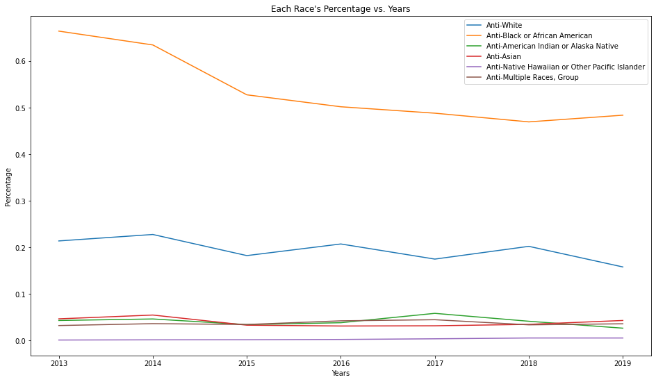

```python
plt.rcParams["figure.figsize"] = [16,9]
for x in range(0,6):

  y = np.array([2013,2014,2015,2016,2017,2018,2019]).reshape(-1, 1)# each year

  z = np.array(Bias_dataPerYear.iloc[x,1:])# each race's row

  race = Bias_dataPerYear.at[x,'Bias'] # add label for each line
  plt.plot(y,z, label=race)


plt.legend()
plt.title("Each Race's Percentage vs. Years")
plt.xlabel("Years")
plt.ylabel("Percentage")
plt.show()
```

How do you think about the graph above? Do you think it fairly reflected how each race experience discrimination in our society because it was plotted based on each race's incidents / total incidents ? If your answer is yes, then you've fallen into our trap HAHAHA! Look into the Normalization part.

**Normalization**

If we want to compare racial hate crimes across races, then normalization can undermine the population related bias in previous data.

From U.S. Census Burearu's Website(https://www.census.gov/quickfacts/fact/table/US/PST045219), we learned about the population construction in the U.S.

And we found that each race has different percentage in the whole U.S. population.

" White alone, percent 76.3%

Black or African American alone, percent 13.4%

American Indian and Alaska Native alone, percent 1.3%

Asian alone, percent 5.9%

Native Hawaiian and Other Pacific Islander alone, percent 0.2%

Two or More Races, percent 2.8%"(from U.S. Census Burearu)

Thus, race with bigger population may have more people to be the victim, which results a higher incident number even they have a less likelihood to be attacked. And smaller population race may have less incidents just because they have less people to be the victim, while each individual is more likely to encounter hate crimes in life.

For example, suppose the total population is constituted by 1000 people in Race A and 10 people in Race B, we found out that each individual in Race A has 1% probability to be a victim of racial hate crime and individuals in Race B have 90% probability to be a victim. And in the report of race hate crime incidents, we would probabily see 19 racial hate crime incidents. 10 of them are from Race A, and 9 of them are from Race B. If we take the percentage of each race's hate crime incidents in the total incidents, we would have 53% for Race A and 47% for Race B. And we may incorrectly conclude that those two race are approximately equal likly to encounter racial hate crimes. But in fact, individuals in Race B are 90 times more likely to be victims of racial hate crimes in this society.

Taking the differences in population percentage in to consideration, we would like to normalize our data, which is setting all races to the same population and then comparing their normalized racial hate crime incidents.

Using the example above, if we want to normalize the racial hate crime incidents in that population, we need to find the ratio between 2 race's population and then multply this ratio to the hate crime incident numbers to the desired group. We see that Race A has a population 100 time larger than Race B, so if we multiply 100 to Race B's population, we will have a imagined Race B who have the same population as Race A. And we can do the same thing to racial hate crime incident number, which would normalize it too. And the incident number would be 900 in this case. To put it in English, we would say if Race B has the same polulation as Race A, then we would expect 900 racial hate crime incidents in the hate crime report. And now we see the 900 racial hate crimes to Race B is 90 times larger than the 10 racial hate crimes to Race A, which preserved the difference between each indicidual's likelyhood of encountering racial hate crimes in two races.

Now, we will aplly normalization to our data and treat white people as the Race A in the previous example. And use the population statistics from U.S. Census Burearu to perform the normalization on each race.

```python
# select needed part from Bias_data
Bias_data_Normalized = Bias_data.iloc[2:,:8]
Bias_data_Normalized = Bias_data_Normalized.reset_index().drop(['index'], axis = 1)

# move column 2019 to the end
Bias_data_Normalized = Bias_data_Normalized[ [ col for col in Bias_data_Normalized.columns if col != '2019' ] + ['2019'] ]

Bia_type = Bias_data_Normalized['Bias']
```

Performing normalization:

We choose white population as our "Race A"'s population because it has the largest population.

```python
# calculate the ratios
ratio = np.array([76.3/76.3, 76.3/13.4, 76.3/1.3, 76.3/5.9, 76.3/0.2, 76.3/2.8]).reshape(-1, 1)
ratio = ratio.astype(int)
print(ratio)

# multiply ratios to the corresponding race
Bias_data_Normalized =  Bias_data_Normalized.mul(ratio,axis = 0)

Bias_data_Normalized['Bias'] = Bia_type
Bias_data_Normalized
```

```
[[  1]
 [  5]
 [ 58]
 [ 12]
 [381]
 [ 27]]
```

|  | Bias | 2013 | 2014 | 2015 | 2016 | 2017 | 2018 | 2019 |
| --- | --- | --- | --- | --- | --- | --- | --- | --- |
| 0 | Anti-White | 728 | 701 | 734 | 876 | 844 | 1001 | 755 |
| 1 | Anti-Black or African American | 11315 | 9775 | 10625 | 10610 | 11790 | 11625 | 11570 |
| 2 | Anti-American Indian or Alaska Native | 8468 | 8236 | 7946 | 9338 | 16298 | 11832 | 7308 |
| 3 | Anti-Asian | 1896 | 2016 | 1584 | 1572 | 1824 | 2052 | 2460 |
| 4 | Anti-Native Hawaiian or Other Pacific Islander | 1143 | 1524 | 2286 | 3429 | 6477 | 9906 | 9525 |
| 5 | Anti-Multiple Races, Group | 2943 | 2997 | 3726 | 4806 | 5805 | 4482 | 4617 |

Now, let's plot the normalized incidents number vs. years!

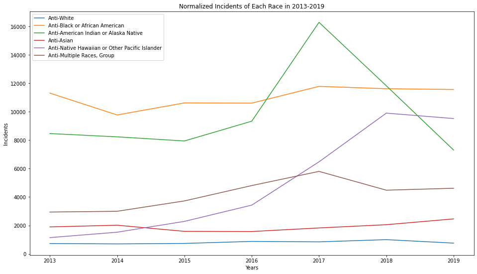

```python
# plot normalized racial crime incidents
plt.rcParams["figure.figsize"] = [16,9]

for x in range(0,6):
  y = np.array([2013,2014,2015,2016,2017,2018,2019]).reshape(-1, 1)
  # get each row
  z = np.array(Bias_data_Normalized.iloc[x,1:])

  race = Bias_data_Normalized.at[x,'Bias']
  plt.plot(y,z, label=race)

plt.title("Normalized Incidents of Each Race in 2013-2019")
plt.xlabel("Years")
plt.ylabel("Incidents")
plt.legend()
plt.show()
```

Let's plot the percentage of each race's incidents in total incidents!

```python
# calculate sum of all incidents in each year
sums = []
for x in range(2013,2020):
  sum = np.sum(Bias_data_Normalized[str(x)])
  sums.append(sum)

sums.insert(0,"All Race") # add sum to the sums array

df_length = len(Bias_data_Normalized)
Bias_data_Normalized.loc[df_length] = sums # add sums to the table
```

```python
# calculate percentage for each race
Bia_type = Bias_data_Normalized['Bias']
Bias_dataPerYear['Bias'] = Bia_type # correct the Bias column

# calculate the percentages
for x in range(2013, 2020):
  Bias_dataPerYear['percentage of ' + str(x)] = Bias_data_Normalized[str(x)] / Bias_data_Normalized[str(x)][6]
```

Let's take a look at this table.

```python
Bias_dataPerYear
```

|  | Bias | percentage of 2013 | percentage of 2014 | percentage of 2015 | percentage of 2016 | percentage of 2017 | percentage of 2018 | percentage of 2019 |
| --- | --- | --- | --- | --- | --- | --- | --- | --- |
| 0 | Anti-White | 0.027479 | 0.0277635 | 0.0272852 | 0.0285985 | 0.0196106 | 0.0244755 | 0.0208362 |
| 1 | Anti-Black or African American | 0.427094 | 0.387144 | 0.394967 | 0.346381 | 0.273944 | 0.284244 | 0.319305 |
| 2 | Anti-American Indian or Alaska Native | 0.319632 | 0.326191 | 0.295379 | 0.304855 | 0.378689 | 0.289305 | 0.201683 |
| 3 | Anti-Asian | 0.0715661 | 0.0798447 | 0.0588826 | 0.0513206 | 0.0423812 | 0.0501736 | 0.0678902 |
| 4 | Anti-Native Hawaiian or Other Pacific Islander | 0.0431435 | 0.0603588 | 0.0849783 | 0.111945 | 0.150495 | 0.242212 | 0.262867 |
| 5 | Anti-Multiple Races, Group | 0.111086 | 0.118698 | 0.138508 | 0.1569 | 0.134881 | 0.10959 | 0.127418 |

Now we have a hate crime data from a "society" that all races have the same population. Let's plot it!

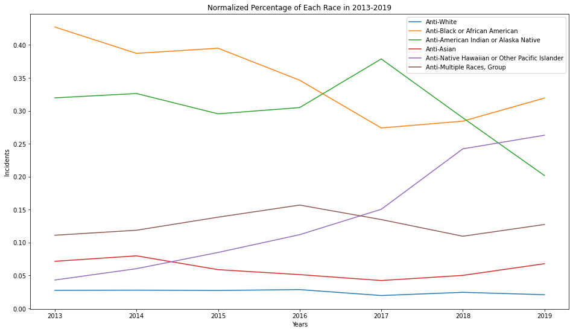

```python
# plot normalized racial crime incidents
plt.rcParams["figure.figsize"] = [16,9]

for x in range(0,6):
  y = np.array([2013,2014,2015,2016,2017,2018,2019]).reshape(-1, 1)
  # get each row
  z = np.array(Bias_dataPerYear.iloc[x,1:])

  race = Bias_dataPerYear.at[x,'Bias']
  plt.plot(y,z, label=race)

plt.title("Normalized Percentage of Each Race in 2013-2019")
plt.xlabel("Years")
plt.ylabel("Incidents")
plt.legend()
plt.show()
```

**Analysis based on previous two graphs (Incidents & Percentage):**

And for the American Indians or Native Americans, we can see that before 2017, they are only less likely to experience discrimination than black people both in the percentage and incidents graph. But in 2017, there is a surge in the racial hate incidents against Native Americans. And we believe this is relevant to the Dakota Access Pipeline event (https://en.wikipedia.org/wiki/Dakota_Access_Pipeline_protests). But after 2017, we see that the percentage and incidents both dropped for Native Americans, which might attribute to the #NoDAPL (https://en.wikipedia.org/wiki/NODAPL) movement.

For Native Hawaiian or Other Pacific Islander, we are very sad to see the percentage and incidents both increased a lot over time. In 2013, both incident and percentage were lower than Anti-Asian hate crimes and slightly more than Anti-White hate crimes, but in 2019, both of them are higher than all races other than African Americans. And our group didn't anticipate this result. Even though we don't know the reason behind this shocking increase of Anti- Native Hawaiian or Other Pacific Islander incidents, we do feel the need of more investivations in the future and the need of support for the Native Hawaiian or Other Pacific Islander group.

Other three races looks more "steady" in 2013-2019.

The Asian Americians are only more likely to experience discrimination than white people from 2015-2019. And there is a slightly increase in incidents after 2016. And our observation is also consistent with the "middle class white" image for Asians in our society. But from our current knowledge, we know it's very likely to have a "surge" in Anti-Asian hate crimes in 2020-2021. And we can see how fragile this "middle class white" image is when there comes a disturbing factor and how difficult it is to eliminate racism.

The white people, as we expected, are least likely to experience discimination. It has the lowest percentage and incidents from 2013-2019.

Now if you look at the previous 'wrong' graph, you can tell how "misleading" it is if you want the comparison across all races.

We can also normalize other 3 tables using the same logic.

For Crime Against Person Incidents:

```python
# building table
CAPersons_data_Normalized = CAPersons_data.iloc[2:] # get needed data
CAPersons_data_Normalized = CAPersons_data_Normalized.reset_index().drop(['index'], axis = 1) # reindex it
CAPersons_data_Normalized =  CAPersons_data_Normalized.mul(ratio,axis = 0) # mulitply by the ratio
CAPersons_data_Normalized['Bias'] = Bia_type # correct the Bias_type
```

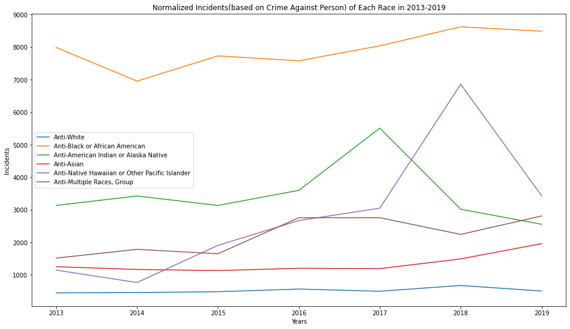

```python
# plot the normalized crime agianst person incidents

for x in range(0,6):
  y = np.array([2013,2014,2015,2016,2017,2018,2019]).reshape(-1, 1)
  # get each row
  z = np.array(CAPersons_data_Normalized.iloc[x,1:])

  race = CAPersons_data_Normalized.at[x,'Bias']
  plt.plot(y,z, label=race)

plt.title("Normalized Incidents(based on Crime Against Person) of Each Race in 2013-2019")
plt.xlabel("Years")
plt.ylabel("Incidents")
plt.legend()
plt.show()
```

We see that black people are much more likely to expericence personal hate crimes than other races in 2013-2019. And the peaks in 2017 and 2018 for Native Americans and Native Hawaiian are also noticeable.

For Crime Against Property Incidents:

```python
# building table
CAProperty_data_Normalized = CAProperty_data.iloc[2:] # get needed data
CAProperty_data_Normalized = CAProperty_data_Normalized.reset_index().drop(['index'], axis = 1) # reindex it
CAProperty_data_Normalized =  CAProperty_data_Normalized.mul(ratio,axis = 0) # mulitply by the ratio
CAProperty_data_Normalized['Bias'] = Bia_type # correct the Bias_type
```

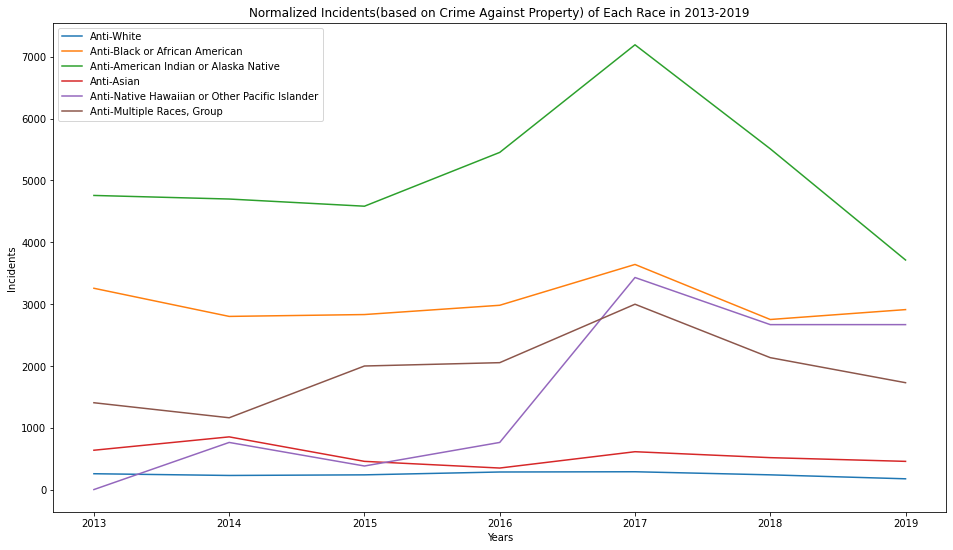

```python
# plot the normalized crime agianst property incidents
for x in range(0,6):
  y = np.array([2013,2014,2015,2016,2017,2018,2019]).reshape(-1, 1)
  # get each row
  z = np.array(CAProperty_data_Normalized.iloc[x,1:])

  race = CAProperty_data_Normalized.at[x,'Bias']
  plt.plot(y,z, label=race)

plt.title("Normalized Incidents(based on Crime Against Property) of Each Race in 2013-2019")
plt.xlabel("Years")
plt.ylabel("Incidents")
plt.legend()
plt.show()
```

We see that American Indian people are much more likely to expericence hate crimes against their propertiesthan other races in 2013-2019.

For Crime Against Society Incidents:

```python
# building table
CASociety_data_Normalized = CASociety_data.iloc[2:] # get needed data
CASociety_data_Normalized = CASociety_data_Normalized.reset_index().drop(['index'], axis = 1) # reindex it
CASociety_data_Normalized =  CASociety_data_Normalized.mul(ratio,axis = 0) # mulitply by the ratio
CASociety_data_Normalized['Bias'] = Bia_type # correct the Bias_type
```

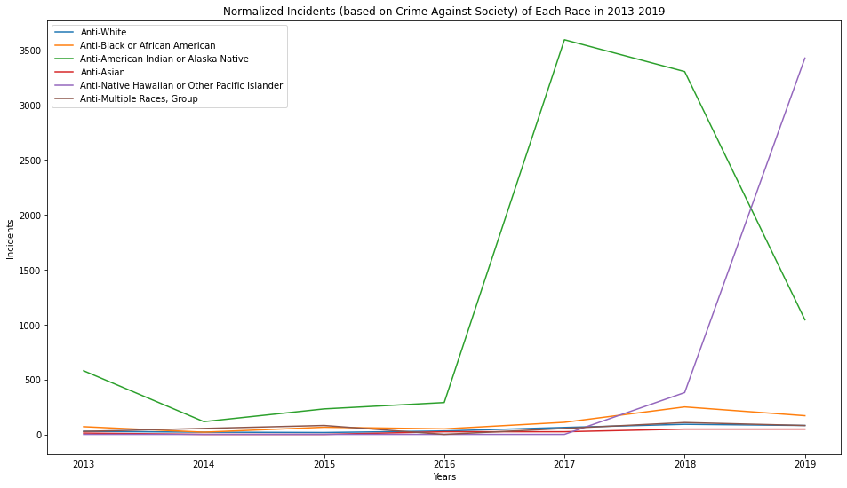

```python
# plot the normalized crime agianst society incidents
for x in range(0,6):
  y = np.array([2013,2014,2015,2016,2017,2018,2019]).reshape(-1, 1)
  # get each row
  z = np.array(CASociety_data_Normalized.iloc[x,1:])

  race = CASociety_data_Normalized.at[x,'Bias']
  plt.plot(y,z, label=race)

plt.title("Normalized Incidents (based on Crime Against Society) of Each Race in 2013-2019")
plt.xlabel("Years")
plt.ylabel("Incidents")
plt.legend()
plt.show()
```

We can see that American Indian and Native Hawaiians are more likly to experience hate crimes against their society than other races.

**3.2 Historical Comparison within the same race**

In this part, we will plot each race individually which would grant us the power to empathsize on the structure of incidents different races have faced. From the previous plots we can tell that each race are facing different amount of racial incidents because of their distinctive historical backgrounds.

However, The three different types of incidents -- Person, Property, and Society -- can explain how each races are being discriminated by various ways. From FBI's documentation, person represents attacks on individuals that are specifically against the person who is being assualted. Property represents attacks on the property owned by the perople of a certain race. Society incidents represent attacks that are targeting the communities and activities of a certain race.

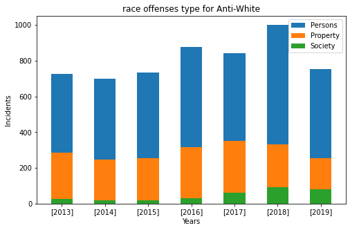

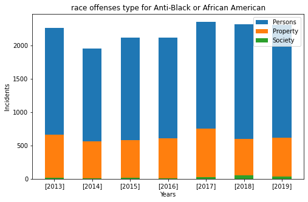

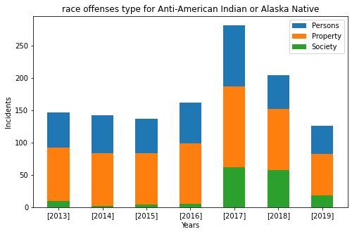

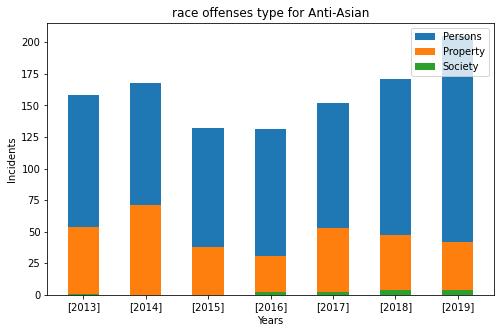

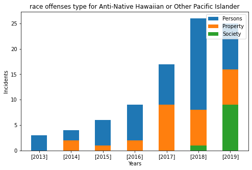

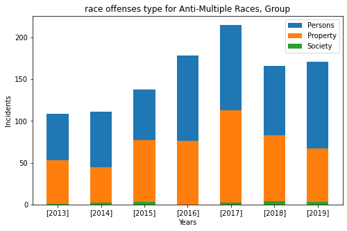

```python
# From the previous part we can tell that each race
# has a drastic differences in the amount of offenses received because of their population difference
# Thus, we would plot each race and compare the types of incidents they received seperately
plt.rcParams["figure.figsize"] = [8,5]
for x in range(0,6):

  # Rearrange the data from years and place in an array
  years = np.array([2013,2014,2015,2016,2017,2018,2019]).reshape(-1, 1)

  # Store Person data in an array
  persons = np.array(CAPersons_data.iloc[x+2,1:])

  # Store Property data in an array
  properties = np.array(CAProperty_data.iloc[x+2,1:])

  # Store Society dara in an array
  societies = np.array(CASociety_data.iloc[x+2,1:])

  race = Bias_dataPerYear.at[x,'Bias']

  ind = [x for x, _ in enumerate(years)]

  total = persons + properties + societies

  # Place each data in bar plots
  plt.bar(ind, persons, width = 0.5, label = 'Persons', bottom = properties + societies)
  plt.bar(ind, properties, width = 0.5, label = 'Property', bottom = societies)
  plt.bar(ind, societies, width = 0.5, label = 'Society')

  # Give information for the plot
  plt.xticks(ind, years)
  plt.ylabel("Incidents")
  plt.xlabel("Years")
  plt.legend(loc="upper right")
  plt.title("race offenses type for "+ str(Bias_dataPerYear.iloc[x,0]))

  plt.show()
```

From the plots above, there are many valuable information. The make up of each race's incidents are drastically different from one another.

There are a few interesting points which can be made from these plots. Anti-White and Anti-Black incidents have a consistent make up of the three types of offenses. The Anti-White incidents have a higher percentage of property offenses, while the Anti-Black incidents are mainly made up of person offenses. On comparison, other races' make up is not as stable, but we can see that American Indians consistently experienced more portion of crimes that against their property, and Asian Americans experienced more portion of personal incidents from 2013 to 2019. Anti-Hawaiian and Pacific Native incidents has seen a huge increase in recent years. It is something worth attention.

## **4. Machine learning and Hypothesis testing**

After analyzed our data, we are equipped with much more understandings about our data. Now let's move to phase 4: machine learning and hypothesis testing. This part can be the most powerful part in data science. We can build models based on current data and use this to make predictions. And we can also test our hypothesis. It can validate our assumptions or answer our questions about our data.

**Machine learning**

Import needed modules for regression

We will primarily utilize sklearn and its linear regression model as our major tool for Machine Learning. scikit-learn(sklearn) is an open source mahine learning tool based in Python. It provides simple and efficient tools for predictive data analysis.

In this case, we are using its linear regression model, because our dataset is mostly linear. Year is the only numerical sources among all dependencies in our dataset.

```python
import seaborn as sns
import statsmodels.api as sm
import sklearn
from statsmodels.formula.api import ols
from sklearn.feature_selection import f_regression
from sklearn import linear_model
```

We will first make a linear regression model using sklearn, then we can use it to predict the trend of each race's incidents number from 2020 to 2026. The linear function would be presented directly on the plot. At the same time, the actual data will be dots on the graph where each race would have its own color.

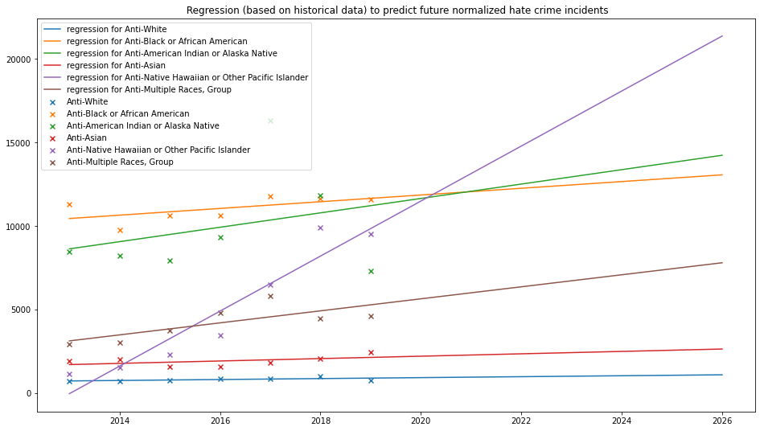

```python
plt.rcParams["figure.figsize"] = [16,9]

for x in range(0,6):# for each race

  y = np.array([2013,2014,2015,2016,2017,2018,2019]).reshape(-1, 1)
  z = np.array(Bias_data_Normalized.iloc[x,1:])# get each row
  model = linear_model.LinearRegression()
  model = model.fit(y,z)  # doing the linear regression
  predict = np.array([2013,2014,2015,2016,2017,2018,2019,2020,2021,2022,2023,2024,2025,2026]).reshape(-1, 1) # years to plot

  race = Bias_data_Normalized.at[x,'Bias'] # get race
  plt.scatter(marker = "x", x = y, y = z, label=str(race)) # scatter each year's incident
  plt.plot(predict, model.predict(predict), label="regression for " + str(race)) # plot the regression line

plt.title(" Regression (based on historical data) to predict future normalized hate crime incidents")
plt.xlabel("Years")
plt.ylabel("Incidents")
plt.legend()
plt.show()
```

From the plot above, we can come up with a thesis: all kinds of racial incidents are increasing. The only differences is their rate of increase. The racial discrimination against Black people are increasing at a much lower rate comparing to the incidents commited against Native people of America: Indians, Hawaiians and other Pacific Islanders. The Black Lives Matter movements in recent years have made some achievements to support the Black community.

And for Asian Americans, we see the regression line is slowly increasing. But from 2021's perspective, we don't think our regression line predicted the surge of Anti-Asian crime incidents in 2020. And this reveals a disadvantage of our model. Our model predicts future incidents by historical data(incidents). It means that, assuming everything is approximately the same as before, this is what we think will happen in the future. But in reality, future is always unpredictable, just like no one foreseen the arrival of COVID-19.

In the machine learning, we see that every race seems to have a increasing trend of experiencing discrimination. But in part three, we see that the incidents are not always increasing for every race in 2013-2019. And this lead us to question: Does racial hate crime incidents increased overtime?

**Hypothesis Testing** (Is incident number increasing over time?)

Now lets make a hypothesis and test it out. First, we have to understanding the definiton of hypothesis testing. Hypothesis testing is a statistical method of determination if your created model is a good fit or not. As the name indicates, a null hypothesis and an alternative hypothesis would be included in a hypothesis testing. We want to set up the hypothesis in such a way that the null hypothesis can be rejected and the hypothesis can be proven true. A significance level(alpha) is the other important indicator for machine learning. If the p value of the random variables is within the significance level, aka the rejection level, the null hypothesis is then rejected.

In our case of racial incidents, we will be looking at the relation between year and total amount of racial incidents. We are looking forward to an linear relation between these two numerical data. Since both of these variables are numerical and related directly without medians, we will be using the linear regression model in statsmodel as the tool to indicate whether therer exists a linearity between the years and the incident numberss.

H0: there is no linearity between the years and the incident numbers

Ha: there is a linearity between the years and the incident numbers

significance level: 0.05

Importing module for hypothesis testing.

```python
import statsmodels.api as sm
from scipy import stats
# since this module needs at least 8 samples to  calculate p-values, we choose to do a regression manually add 2012's incidents to our data
```

Using statmodels to calculate P-values.

```python
year = [x for x in range(2009,2020)] # build years for independent variable
year = np.array(year, dtype=np.float).reshape(-1, 1)

# we manully collected data for 2009-2012 because it's more efficient
# Add them to the preious data
z = np.array(Bias_data.iloc[1,1:8],dtype=np.float) # get incidents number from 2013-2019
z = np.insert(z,0,2797, axis=0) # add racial hate crime incidents in 2012
z = np.insert(z,0,2917, axis=0) # 2011: 2917
z = np.insert(z,0,3135, axis=0) # 2010: 3135
z = np.insert(z,0,3199, axis=0) # 2009: 3199

# use the linear regression model in statsmodels
y2 = sm.add_constant(year)
est = sm.OLS(z, y2)
est2 = est.fit()
print(est2.summary())
```

```
                            OLS Regression Results
==============================================================================
Dep. Variable:                      y   R-squared:                       0.793
Model:                            OLS   Adj. R-squared:                  0.770
Method:                 Least Squares   F-statistic:                     34.44
Date:                Sun, 16 May 2021   Prob (F-statistic):           0.000238
Time:                        14:21:22   Log-Likelihood:                -80.327
No. Observations:                  11   AIC:                             164.7
Df Residuals:                       9   BIC:                             165.4
Df Model:                           1
Covariance Type:            nonrobust
==============================================================================
                 coef    std err          t      P>|t|      [0.025      0.975]
------------------------------------------------------------------------------
const      -4.436e+05   7.62e+04     -5.819      0.000   -6.16e+05   -2.71e+05
x1           222.1091     37.848      5.868      0.000     136.491     307.728
==============================================================================
Omnibus:                        0.443   Durbin-Watson:                   1.184
Prob(Omnibus):                  0.801   Jarque-Bera (JB):                0.469
Skew:                          -0.359   Prob(JB):                        0.791
Kurtosis:                       2.288   Cond. No.                     1.28e+06
==============================================================================

Warnings:
[1] Standard Errors assume that the covariance matrix of the errors is correctly specified.
[2] The condition number is large, 1.28e+06. This might indicate that there are
strong multicollinearity or other numerical problems.
```

And in the P>|t| we can see that, the p-value is nearly zero and less than our significance level (0.05). So we can reject the null hypothesis.

We may then conclude that there exist a linear relationship between year and racial hate crime incidents in 2009-2019. The model tells that the increase in racial incidents per year is 222.11 with a standard error of 37.85. These will be the number we are using for the prediction about the future.

Now let's plot the regression line using Sklearn and make a prediction about future 10 year's incident numbers.

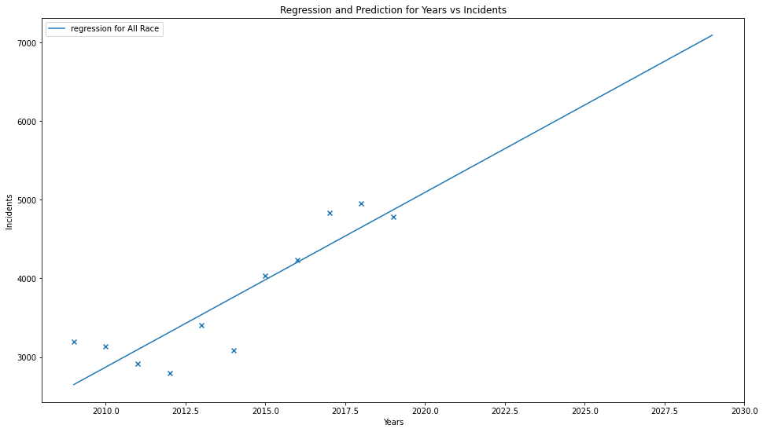

```python
# use SkLearn's linear regression model
model = linear_model.LinearRegression()
model = model.fit(year,z)
predict = np.array([x for x in range(2009,2030)],dtype=np.float).reshape(-1, 1) # for regression and prediction


plt.scatter(marker = "x", x = year, y = z) # scatter data
plt.plot(predict, model.predict(predict), label="regression for " + "All Race") # plot prediction and regression
plt.title("Regression and Prediction for Years vs Incidents")
plt.xlabel("Years")
plt.ylabel("Incidents")
plt.legend()
plt.show()
```

From this regression line and our p-value test, we are very sad to see that the racial hate crimes do increases overtime.

But do you remember the disadvantage of our prediction model? It can only predict the future incidents ASSUMING everthing is the same as the past. Eventhough there are possibility that we will met incidents, like COVID-19, that will increase racial hate crimes in our society, it is also possible that the movement and the education of racial equality will gradually change our slope from positive to negative!

**5. Conclusion**

Data is not just numbers. There are real people, real incidents, real feelings, real pains and real tears behind every "1". As data scientists, our job is to manipulate and analyze data in an objective way and avoid unintentional misconception during this process so that we can respect the true incidents behind our data subjectively.